# Visualisierungen mit ggplot am Beispiel AutoEU

Manfred Brill

# Benötigte Packages für diese Datei

In diesem Markdown-Dokument werden die folgenden Packages eingesetzt:

- tidyverse
- kableEtra
- RColorBrewer
- GGally

Als Datensatz betrachten wir *AutoEU*.

# Der Datensatz *AutoEU*

Dieser Datensatz ist aus dem im Package *ISLR* ((Gareth et al. 2013)) enthaltenen Datensatz *auto* entstanden. Die Null-Werte wurden entfernt und die Einheiten und Bezeichnungen auf unseren Sprachgebrauch angepasst. Nach dem Einlesen stellen wir mit *as_factor* sicher, dass einige Merkmale korrekt als Faktoren interpretiert werden, was für die Visualisierung mit *ggplot* sehr hilfreich ist.

```r
daten <- read_csv2(file="data/AutoEU.csv")
```

```
i Using "','" as decimal and "'.'" as grouping mark. Use `read_delim()` for more control.
```

```r
daten$Region <- as_factor(daten$Region)
daten$Zylinder <- as_factor(daten$Zylinder)
daten$Baujahr <- as_factor(daten$Baujahr)

kable(head(daten),
      align="l") %>%
      kable_styling(bootstrap_options = c("striped", "condensed"),
                full_width = T,
                position = "center")
```

| Name | Region | Baujahr | Zylinder | Hubraum | Gewicht | Verbrauch | PS | Beschleunigung |
| --- | --- | --- | --- | --- | --- | --- | --- | --- |
| chevrolet chevelle malibu | USA | 1970 | 8 | 5.03 | 1.59 | 13.1 | 132 | 12.0 |
| buick skylark 320 | USA | 1970 | 8 | 5.74 | 1.68 | 15.7 | 167 | 11.5 |
| plymouth satellite | USA | 1970 | 8 | 5.21 | 1.56 | 13.1 | 152 | 11.0 |
| amc rebel sst | USA | 1970 | 8 | 4.98 | 1.56 | 14.7 | 152 | 12.0 |
| ford torino | USA | 1970 | 8 | 4.95 | 1.56 | 13.8 | 142 | 10.5 |
| ford galaxie 500 | USA | 1970 | 8 | 7.03 | 1.97 | 15.7 | 201 | 10.0 |

# Visualisierungen

## Boxplots

```r
box <- ggplot(daten,
              aes(x=Region, y=Verbrauch, fill=Region)) +
  geom_boxplot(color="black",
               outlier.colour = "black") +
  scale_fill_brewer(palette="Pastel2") +
  scale_x_discrete(limits=c("Europa", "Japan", "USA"))
  labs(
    title="Datensatz autoEU",
    subtitle="",
    x = " ",
    y = "Verbrauch in l/100 km"
  )
```

```
$x
[1] " "

$y
[1] "Verbrauch in l/100 km"

$title
[1] "Datensatz autoEU"

$subtitle
[1] ""

attr(,"class")
[1] "labels"
```

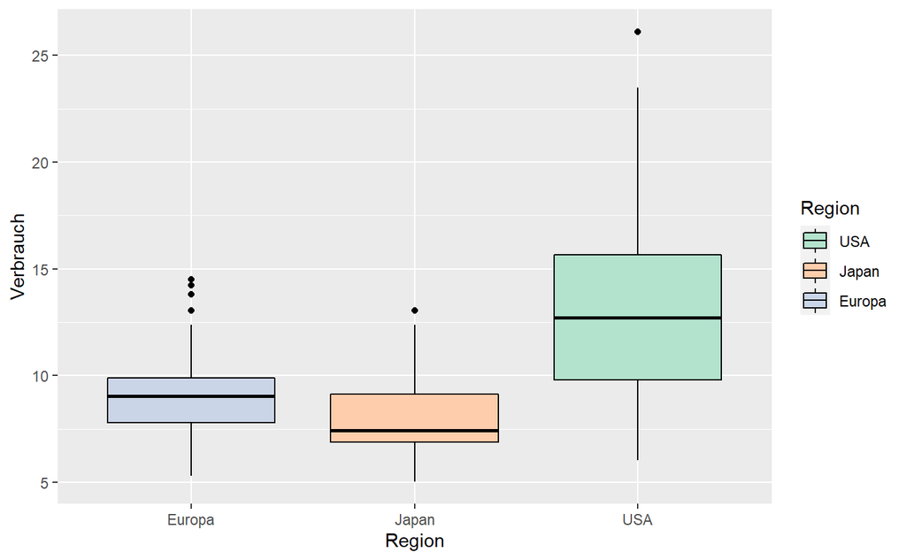

```r
box

ggsave(filename="autoEUBox1.png", plot=last_plot(), device="png",
       path="images/", width=16, height=9, units="cm")
```

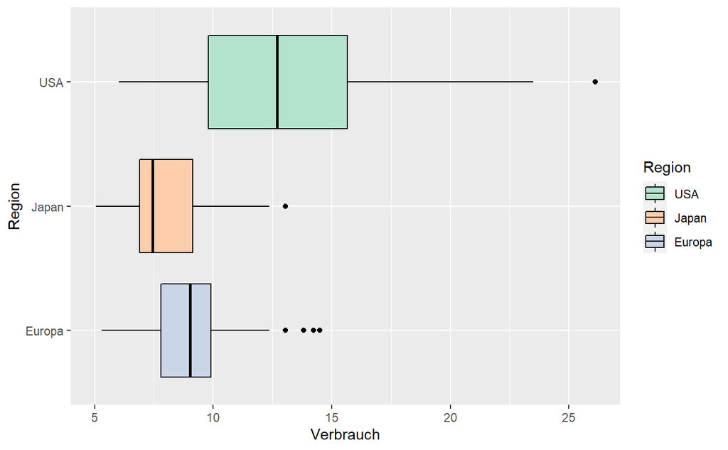

```r
box + coord_flip()
```

Wir können die Kategorien auf der x-Achse auch verändern, indem wir zum Beispiel *x=Zylinder* zuweisen.

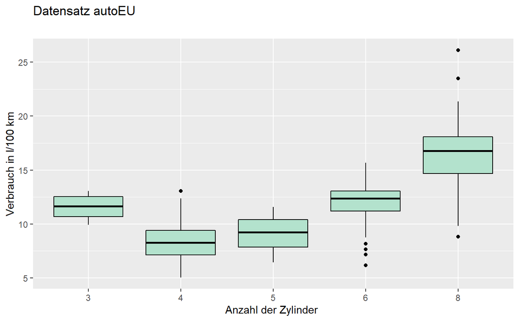

```r
ggplot(daten,
       aes(x=Zylinder, y=Verbrauch)) +
  geom_boxplot(fill= myPalette[1],
               color="black",
              outlier.colour = "black") +
  labs(
    title="Datensatz autoEU",
    subtitle="",
    x = "Anzahl der Zylinder ",
    y = "Verbrauch in l/100 km"
  )

ggsave(filename="autoEUBox2.png",
       plot=last_plot(), device="png",
       path="images/",
       width=16, height=9, units="cm")
```

Wir fügen die Region noch für die Füllfarbe ein. Dabei verwenden wir *geom_boxplot* in einer Pipeline, in der wir filtern. Zusätzlich sorgen wir mit *scale_y_continous* dafür, dass wir gleiche y-Achsen haben! Achten Sie bei solchen Darstellungen immer auf korrekte Skalierungen auf den Achsen. Sonst können wir die grafischen Darstellungen nur sehr schwer interpretieren!

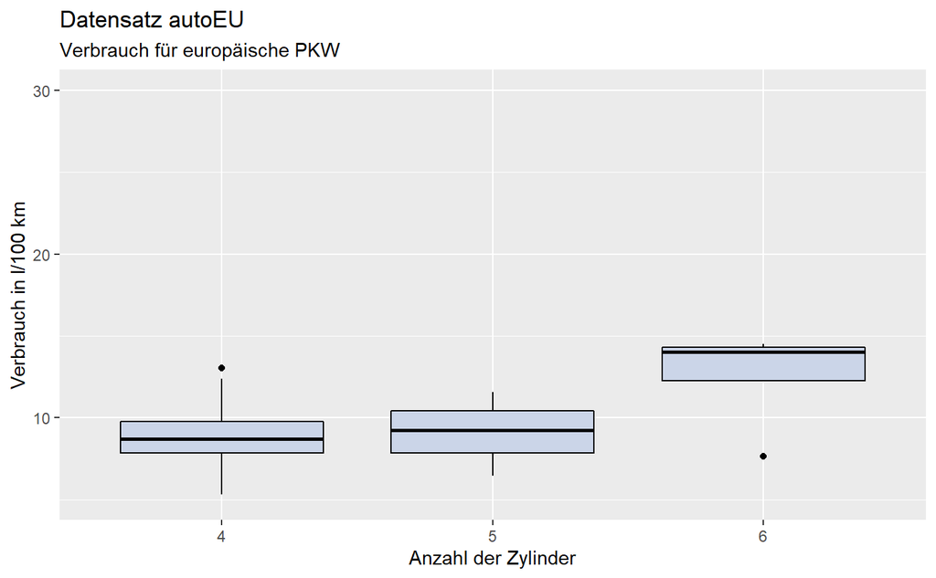

```r
wanted <- "Europa"

daten %>%
  group_by(Region) %>%
  filter(
    Region == wanted
  ) %>%
  ggplot(aes(x=Zylinder, y=Verbrauch)) +
  geom_boxplot( fill=myPalette[3],
                color="black",
                outlier.colour = "black") +
   scale_y_continuous(limits = c(5, 30)) +
   labs(
    title="Datensatz autoEU",
    subtitle="Verbrauch für europäische PKW",
    x = "Anzahl der Zylinder",
    y = "Verbrauch in l/100 km"
  ) +
  theme(legend.position = "none")

ggsave(filename="autoEUBox4.png",
       plot=last_plot(),
       device="png",
       path="images/",
       width=16, height=9, units="cm")
```

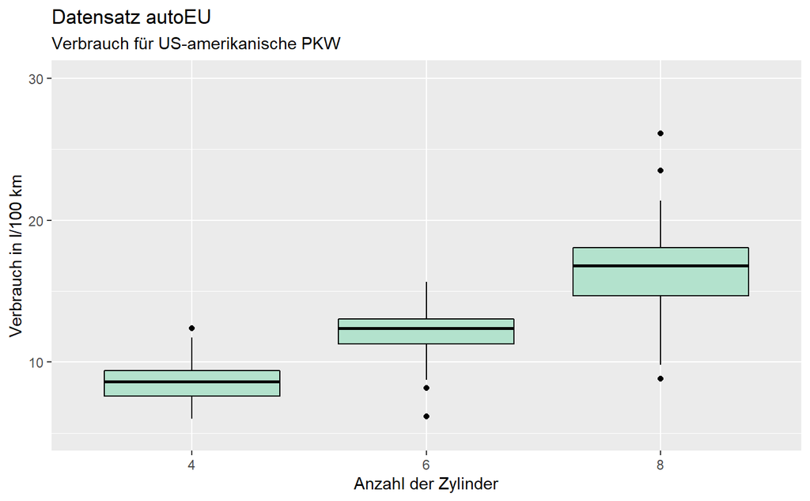

```r
wanted <- "USA"

daten %>%
  group_by(Region) %>%
  filter(
    Region == wanted
  ) %>%
  ggplot(aes(x=Zylinder, y=Verbrauch)) +
  geom_boxplot( fill=myPalette[1],
                color="black",
                outlier.colour = "black") +
  scale_y_continuous(limits = c(5, 30)) +
  labs(
    title="Datensatz autoEU",
    subtitle="Verbrauch für US-amerikanische PKW",
    x = "Anzahl der Zylinder",
    y = "Verbrauch in l/100 km"
  ) +
  theme(legend.position = "none")

ggsave(filename="autoEUBox5.png",
       plot=last_plot(), device="png",
       path="images/",
       width=16, height=9, units="cm")
```

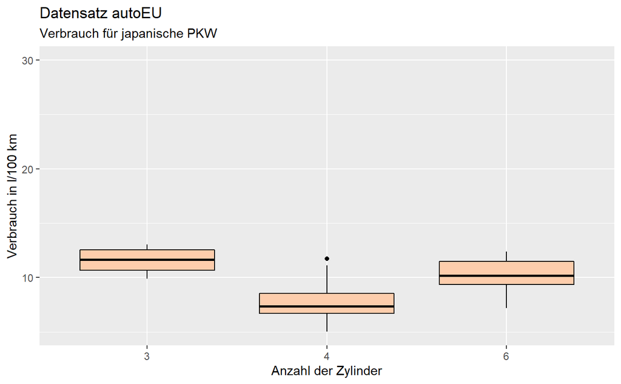

```r
wanted <- "Japan"

daten %>%
  group_by(Region) %>%
  filter(
    Region == wanted
  ) %>%
  ggplot(aes(x=Zylinder, y=Verbrauch)) +
  geom_boxplot( fill=myPalette[2],
                color="black",
                outlier.colour = "black") +
  scale_y_continuous(limits = c(5, 30)) +
  labs(
    title="Datensatz autoEU",
    subtitle="Verbrauch für japanische PKW",
    x = "Anzahl der Zylinder",
    y = "Verbrauch in l/100 km"
  ) +
  theme(legend.position = "none")

ggsave(filename="autoEUBox6.png",
       plot=last_plot(), device="png",
       path="images/",
       width=16, height=9, units="cm")
```

## SPLOM mit ggpairs

```r
ggpairs(daten,
        columns=5:9,
        title="Scatterplot-Matrix für den Datensatz AutoEU",
        aes(color = myPalette[3]),
        #diag = "blank",
        upper = "blank"
        )
```

[output not shown]

[output not shown]

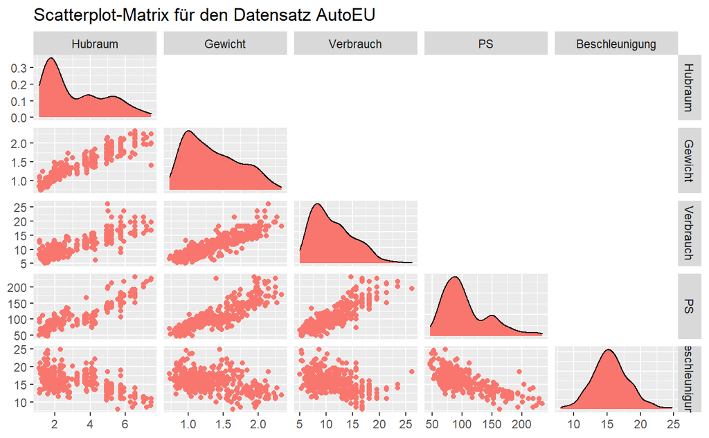

```r
ggsave(filename="autoEUpairs1.png",
       plot=last_plot(),
       device="png",
       path="images/",
       width=16, height=9,
       units="cm")
```

```r
daten %>%
  filter(Hubraum < 1.3) %>%
  ggpairs(columns=5:9,
          title="Scatterplot-Matrix für den Datensatz AutoEU (Hubraum < 1300 l)",
          aes(color = myPalette[3]),
          #diag = "blank",
          upper = "blank")
```

[output not shown]

[output not shown]

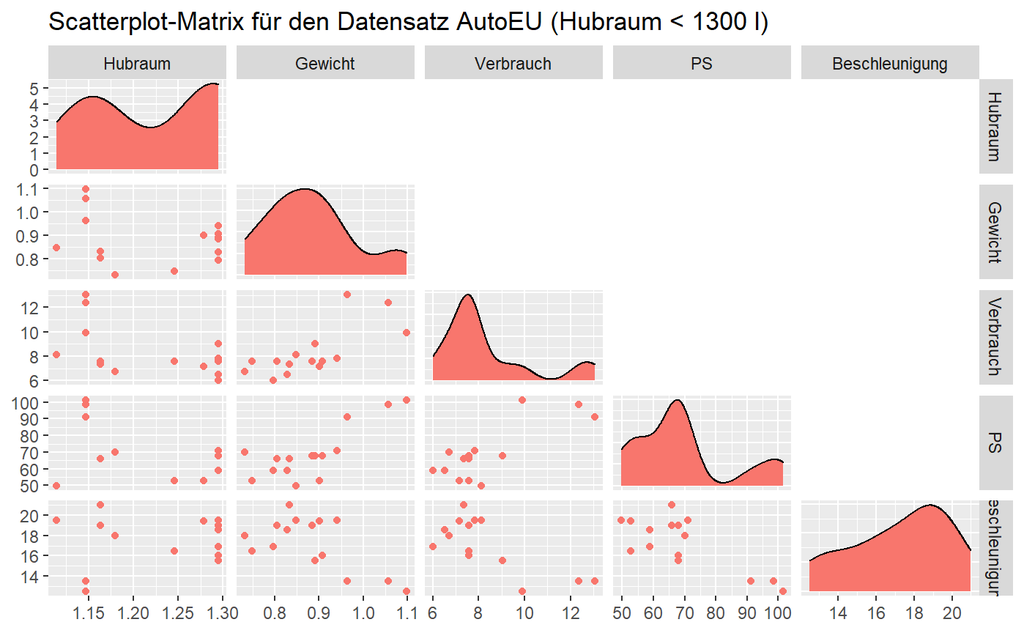

```r
ggsave(filename="autoEUpairs2.png",
       plot=last_plot(),
       device="png",
       path="images/",
       width=16, height=9,
       units="cm")
```

## SPLOM mit ggplot und facets

In *ggplot* können wir sogenannte Facets mit *facet_grid* und *facet_wrap* verwenden.

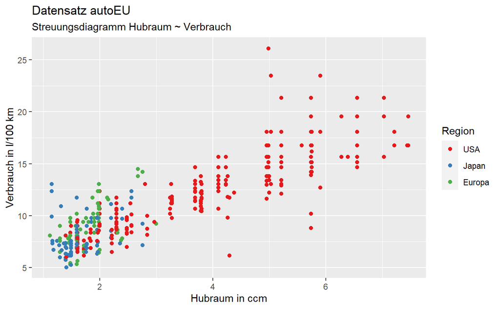

```r
# Basisplot
auto_plot <- ggplot(daten,
                    aes(x = Hubraum,
                        y = Verbrauch,
                        color=Region)) +
  geom_point(shape=20, size=2.5) +
  scale_color_brewer(palette="Set1")

auto_plot +
    labs(
    title="Datensatz autoEU",
    subtitle="Streuungsdiagramm Hubraum ~ Verbrauch",
    x = "Hubraum in ccm",
    y="Verbrauch in l/100 km"
  )

ggsave(filename="autoEUGrid0.png",
       plot=last_plot(),
       device="png",
       path="images/",
       width=16, height=9,
       units="cm")
```

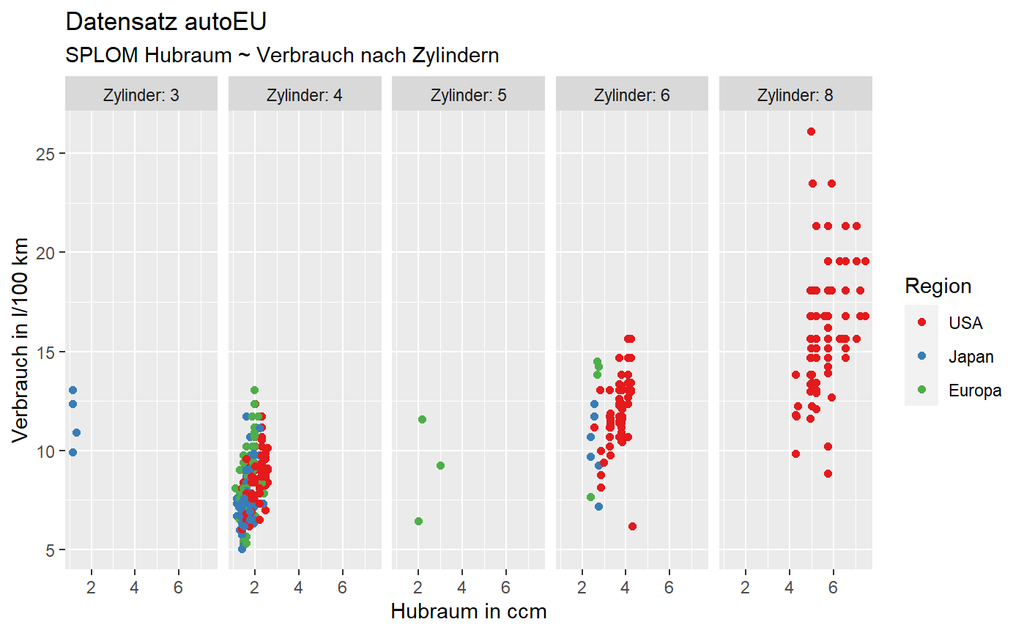

```r
# Jetzt erzeugen wir einen grid
# Zylinder erzeugt Spalten
auto_plot +
  facet_grid(. ~ Zylinder,
             labeller = label_both) +
  labs(
    title="Datensatz autoEU",
    subtitle="SPLOM Hubraum ~ Verbrauch nach Zylindern",
    x = "Hubraum in ccm",
    y="Verbrauch in l/100 km"
  )

ggsave(filename="autoEUGrid1.png",
       plot=last_plot(), device="png",
       path="images/",
       width=16, height=9, units="cm")
```

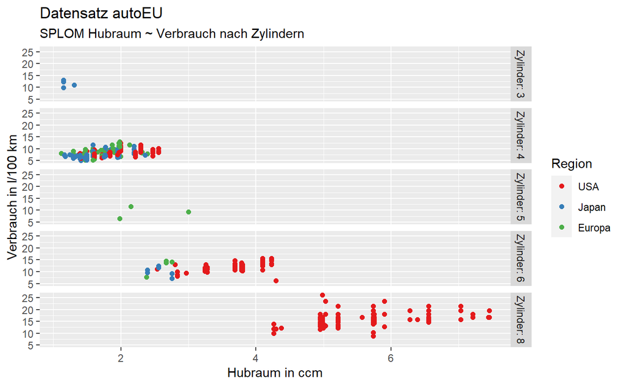

```r
# Zylinder erzeugt Zeilen
auto_plot +
  facet_grid(Zylinder ~ .,
             labeller = label_both) +
  labs(
    title="Datensatz autoEU",
    subtitle="SPLOM Hubraum ~ Verbrauch nach Zylindern",
    x = "Hubraum in ccm",
    y="Verbrauch in l/100 km"
  )

ggsave(filename="autoEUGrid2.png",
       plot=last_plot(), device="png",
       path="images/",
       width=16, height=9, units="cm")
```

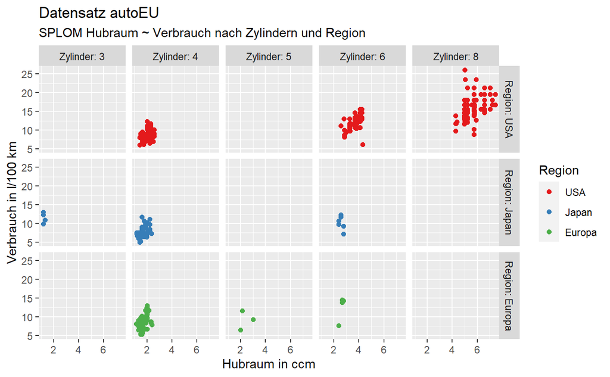

```r
# Beides
auto_plot +
  facet_grid(Region ~ Zylinder, labeller = label_both) +
  labs(
    title="Datensatz autoEU",
    subtitle="SPLOM Hubraum ~ Verbrauch nach Zylindern und Region",
    x = "Hubraum in ccm",
    y="Verbrauch in l/100 km"
  )

ggsave(filename="autoEUGrid3.png", plot=last_plot(), device="png",
       path="images/", width=16, height=9, units="cm")
```

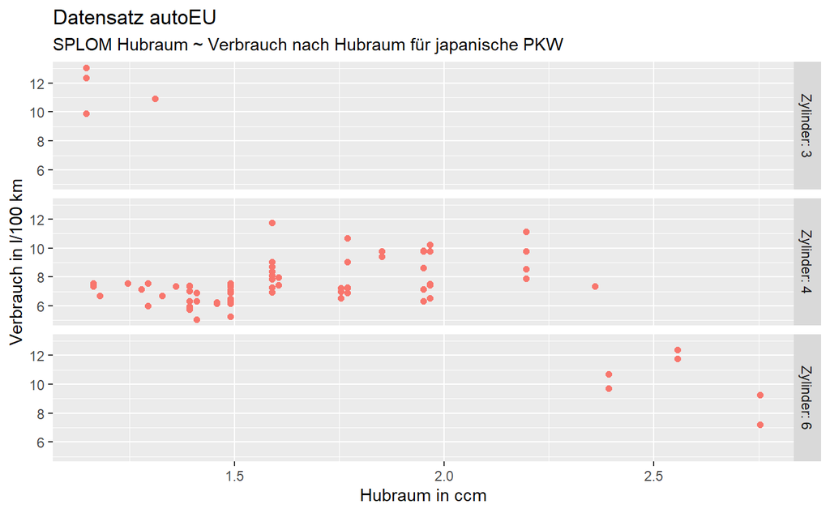

```r
wanted <- "Japan"
daten %>%
   group_by(Region) %>%
   filter(
     Region == wanted
   ) %>%
  ggplot(aes(x = Hubraum, y = Verbrauch, color=Region)) +
  geom_point(shape=20, size=2.5) +
  scale_color_brewer(palette="Set3", aesthetics="fill") +
  facet_grid(Zylinder ~ ., labeller = label_both) +
  labs(
    title="Datensatz autoEU",
    subtitle="SPLOM Hubraum ~ Verbrauch nach Hubraum für japanische PKW",
    x = "Hubraum in ccm",
    y="Verbrauch in l/100 km"
  ) +
    theme(legend.position = "none")

ggsave(filename="autoEUSPLOMJapan.png", plot=last_plot(), device="png",
       path="images/", width=16, height=9, units="cm")
```

[figure not shown]

# Literatur

Gareth, Witten, Hastie, and Tibshirani. 2013. *An Introduction to Statistical Learning with Applications in r*. Springer.